# Fitting a Spatial model with `inlabru`

Day 2, Morning

Instructor: Sara Martino

In this practical we are going to fit a spatial model for the montly mean maximim temperature in Italy.

The goals of this practical are:

- Learn how to fit a spatial model in `inlabru`
- Learn how to do predictions
- Learn how to simulate from the fitted model

Start by loading usefull libraries:

```r
library(INLA)
library(ggplot2)
library(patchwork)
# load some libraries to generate nice map plots
library(inlabru)
library(tidyverse)
library(sp)
library(sf)
library(viridis)
library(raster)
```

# 1 The data

We are going to look at the montly mean maximum temperatures in Italy in January 2020.

Load the data and a shapefile for the italian territory.

```r
italy = st_read("Data/Temp_Italia/italia_km.shp")
# remove the crs information
# This is not necessary but we want to keep things simple here!
st_crs(italy) = "NA"
temp = read.table("Data/Temp_Italia/Temp_italia_january2020.dat")

#transform the coordinated from meter to Km
temp$x = temp$x/1000
temp$y = temp$y/1000

# add latitude as a own column
temp$lat = temp$y

# create a spatilPoligonDataframe
italy_sp = as(italy,"Spatial")
```

We can have a look at the data:

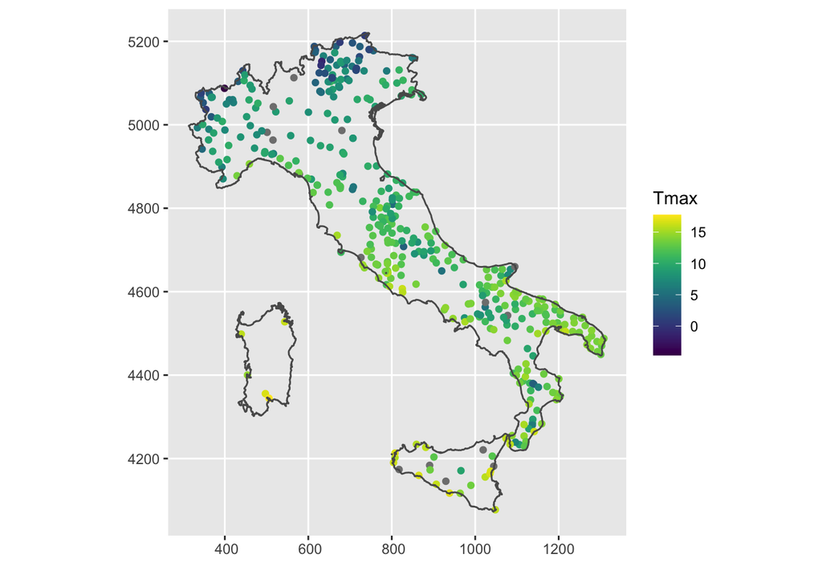

```r
ggplot() + geom_point(data = temp, aes(x,y,color = Tmax)) +
  geom_sf(data = italy, alpha = 0) +
  scale_color_viridis() + xlab("") + ylab("")
```

The dataset also contains information about the altitude of the measuring stations.

We are going to use both elevation and latitude as covariates

**Exercise 1:** Explore the dataset. Is a Gaussian likelihood reasonable? Do we have reason to believe that elevation and latitude explain (part) of the variability in the Tmax variable?

# 2 The model

We are going to fit the following model

$$\begin{aligned}
Y(s) &\sim \mathcal{N}(\eta(s),\sigma^2_y)\\
\eta(s)& = \alpha + \beta_1\ x_1(s) + \beta_2x_2(s) + u(s)\\
\end{aligned}$$
Where

- $Y(s)$ is the temperature at location $s$
- $x_1(s)$ and $x_2(s)$ are altitude and latitude at location $s$
- $\beta_1$ and $\beta_2$ are parameters
- $\alpha$ is a common intercept
- $u(s)$ is a Matern field with range $\rho$ and standard deviation $\sigma_u$
- $\sigma^2_y$ is the observation error.

# 3 Create the mesh

We can create the mesh starting from the observation points as:

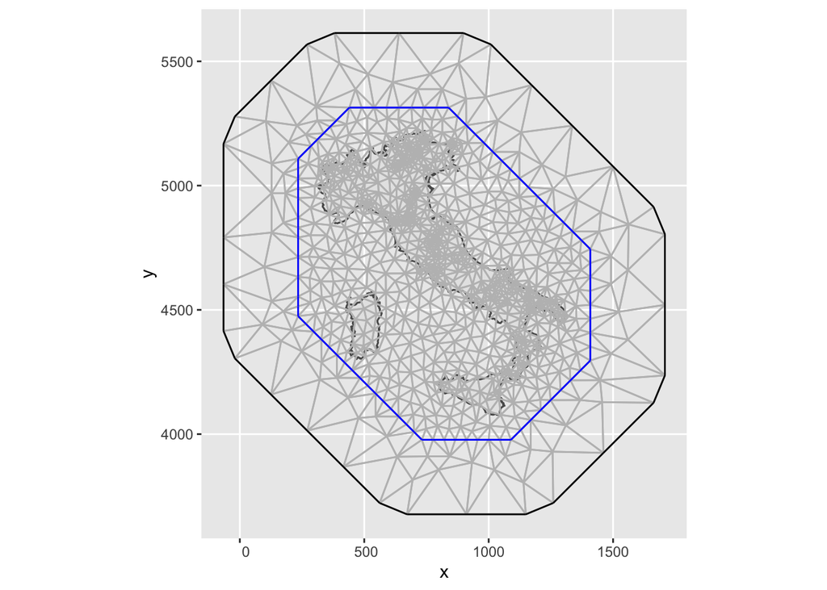

```r
mesh1 = inla.mesh.2d(loc = cbind(temp$x, temp$y),
                     offset = c(100,300),
                     max.edge = c(80,400))
ggplot() + geom_sf(data = italy) + gg(mesh1)
```

This will create a mesh vertex in each station. Many stations are very close to each other thus creating a lot of small triangles.

We can avoid this by using the option `cutoff = K`. This will make the mesh builder consider all points closer that `K` as one:

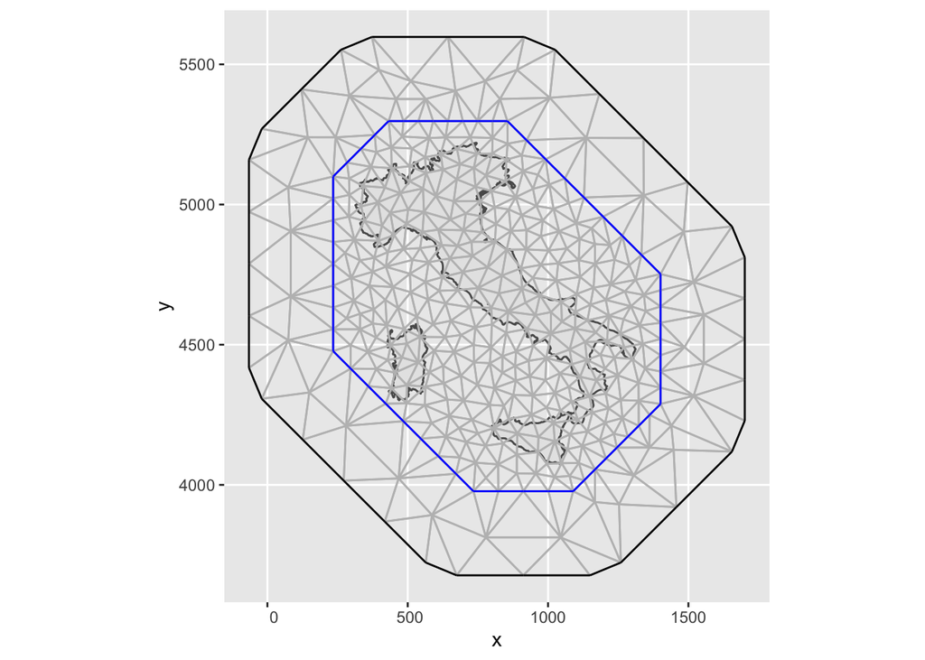

```r
# create the mesh
mesh2 = inla.mesh.2d(loc = cbind(temp$x, temp$y),
                    cutoff = 50,
                     offset = c(100,300),
                     max.edge = c(80,400))
ggplot() + geom_sf(data = italy) + gg(mesh2)
```

# 4 The SPDE model

To create the SPDE representation of the GAussian field we need to specify the priors for the range $\rho$ and the standard deviation $\sigma_u$.

Below are some possibilities:

```r
# spde model
spde1 = inla.spde2.pcmatern(mesh = mesh2,
                           prior.range=c(10,0.5),
                           prior.sigma=c(20,0.1))

spde2 = inla.spde2.pcmatern(mesh = mesh2,
                           prior.range=c(1500,0.5),
                           prior.sigma=c(0.1,0.1))

spde3 = inla.spde2.pcmatern(mesh = mesh2,
                           prior.range=c(150,0.5),
                           prior.sigma=c(2,0.1))
```

**Exercise 2:** Check the sd of the `Tmax` variable the data set, which of the 3 priors above seems to be reasonable?

# 5 Running the model

To run the model we need to make our dataset a spatial object (we need to define where our coordinates are!)

We want to use both `Elevation` and `lat` as linear covariates. These are already present in the `temp` dataset so we can use them directly in the model.

The model is then defined as:

```r
# define the coordinates
coordinates(temp) = c("x","y")
# model component
cmp  = ~ Intercept(1) +
  SPDE(coordinates, model = spde) +
  Elevation(Elevation, model = "linear") +
  lat(lat, model = "linear")
# likelihood
lik = like(formula = Tmax ~ Intercept + SPDE + Elevation + lat  ,
           family = "gaussian",
           data = temp)

# fit the model
fit = bru(cmp, lik,
          options = list(verbose = F,
                         bru_max_iter = 1,
                         inla.mode  = "experimental"))
```

**Exercise 3:** Check the model results. Are the covariate significant? what are the posterior for the range $\rho$ and the standard deviation $\sigma_u$?

# 6 Spatial prediction

We now want to predict the mean montly maximum temperature over Italy.

To do this we need, of course, the value of the elevation and latitude over the whole area of interest.

The can be read as:

```r
dem_sp = readRDS("Data/Temp_Italia/dem.RDS")
```

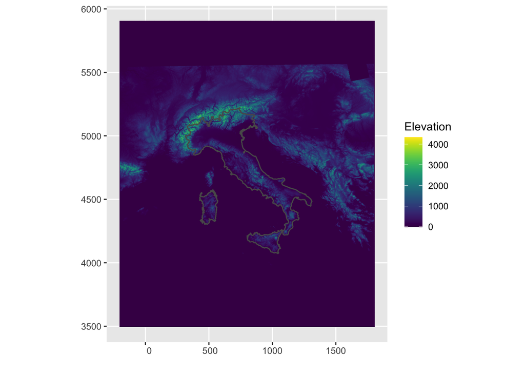

First thing to do is to define the area taht we want to predict over. For this we can use the function `pixels()`

```r
pxl = pixels(mesh2, nx = 400, ny = 400, mask = italy_sp)
```

This creates a grid covering the whole mesh with dimension 400x400. The option `mask = italy_sp` removes all points that are outside of the italian border:

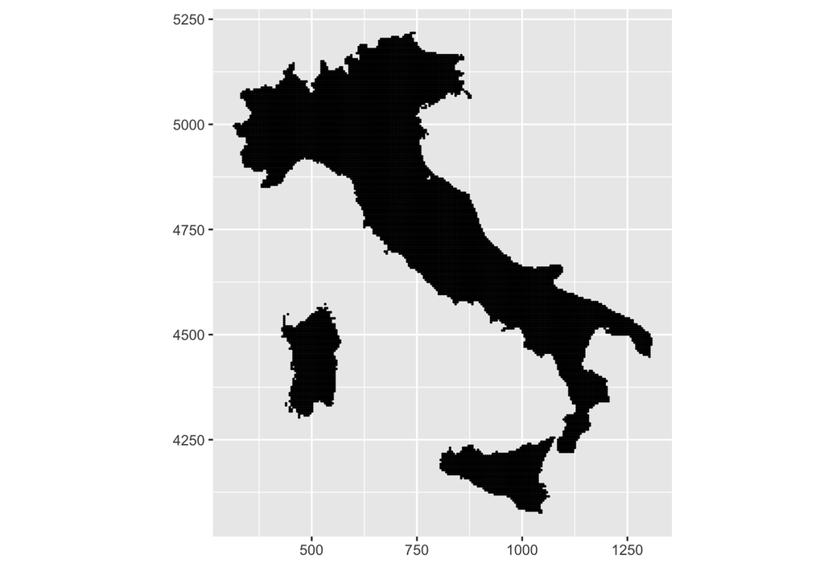

To compute predictions we need to have the values of covariates on every point in the `pxl` object. There are several ways to do that. Here we use the function `extract()` from the `raster` library:

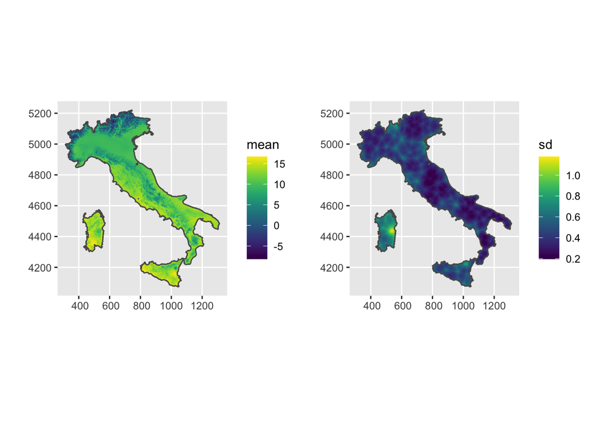

```r
# Create a raster with altitude values
rast = raster::raster(dem_sp)
# extract altitude at the points of interest
val  = raster::extract(rast, coordinates(pxl))

pxl <- cbind(pxl, data.frame(lat = coordinates(pxl)[,2],
                             Elevation = val))

# use the predict() function to create predictions
pred_space = predict(fit, pxl,
                        ~ Intercept + SPDE+ Elevation + lat)

# plot postrior mean and sd
p1 = ggplot() + gg(pred_space, aes(fill = mean)) +
  geom_sf(data = italy, alpha = 0) +
  scale_fill_viridis() + xlab("") + ylab("")
p2 = ggplot() + gg(pred_space, aes(fill = sd)) +
  geom_sf(data = italy, alpha = 0) +
  scale_fill_viridis() + xlab("") + ylab("")
p1+p2
```

**Exercise 4:** Use the function `predict()` to look at the posterior mean and standard deviation of the Gaussian field $u$. Use the function `generate()` to generate samples from the fitted model.

# 7 One alternative formulation

If we are interested in prediction surfaces and we have the covariates over the whole surface we can also use the grdi directly as input for the `bru()` function:

```r
cmp1  = ~ Intercept(1) +
  SPDE(coordinates, model = spde) +
  Elevation(dem_sp, model = "linear") +
  lat(lat, model = "linear")
# likelihood
lik1 = like(formula = Tmax ~ Intercept + SPDE + Elevation + lat  ,
           family = "gaussian",
           data = temp)

# fit the model
fit1 = bru(cmp1, lik1,
          options = list(verbose = F,
                         bru_max_iter = 1,
                         inla.mode  = "experimental"))
```

Prediction can then be obtained as:

```r
pxl = pixels(mesh2, nx = 400, ny = 400, mask = italy_sp)

pxl <- cbind(pxl, data.frame(lat = coordinates(pxl)[,2]))
pred_space = predict(fit, pxl,
                        ~ Intercept + SPDE+ Elevation + lat)
```